# Simulating a simulation study

Alessandro Gasparini

2018-06-20

# Introduction

In this vignette, we show how the simulated data included as an example dataset in `simsum` has been generated.

# Motivation

Say we want to run a simulation study in which we want to compare the sensitivity of parametric and semiparametric survival models on relative risk estimates.

# Data generating mechanisms

We simulate an hypotetical trial with a binary treatment. We fix the log-treatment effect to $-0.50$, and we generate a treatment indicator variable for each simulated individual via a $Binom(1, 0.5)$ random variable. We simulate two different sample sizes (50 and 250 individuals) and we assume two different baseline hazard functions: exponential with scale parameter $\lambda = 0.5$, and Weibull with scale parameter $\lambda = 0.5$ and shape parameter $\gamma = 1.5$. Finally, we apply administrative censoring at time $t = 5$.

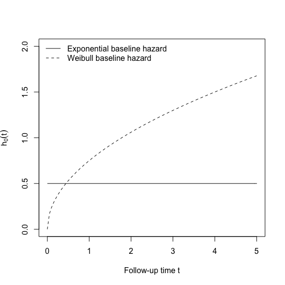

```r
exp_basehaz <- function(t, lambda = 0.5) lambda * 1 * t^0
exp_weibull <- function(t, lambda = 0.5, gamma = 1.5) lambda * gamma * t^(gamma - 1)
curve(exp_basehaz, from = 0, to = 5, lty = 1, ylim = c(0, 2), ylab = expression(h[0](t)), xlab = "Follow-up time t")
curve(exp_weibull, from = 0, to = 5, lty = 2, add = TRUE)
legend(x = "topleft", lty = 1:2, legend = c("Exponential baseline hazard", "Weibull baseline hazard"), bty = "n")
```

The survival times are estimated using the approach of Bender *et al*. (2005), based on drawing from a $U(0, 1)$ random variable and applying the following transformations:

1. for an exponential baseline hazard, the survival time $t$ is simulated as:
   $$t = -\frac{log(U)}{\lambda \exp(\beta ^ T X)}$$
2. for a Weibull baseline hazard, the survival time $t$ is simulated as:
   $$t = \left(-\frac{log(U)}{\lambda \exp(\beta ^ T X)}\right) ^ {1 / \gamma}$$

The R function to simulate a dataset for our simulation study is defined as follows:

```r
simulate_data <- function(dataset, n, baseline, params = list(), coveff = -0.50) {
  # Simulate treatment indicator variable
  x <- rbinom(n = n, size = 1, prob = 0.5)
  # Draw from a U(0,1) random variable
  u <- runif(n)
  # Simulate survival times depending on the baseline hazard
  if (baseline == "Exponential") {
    t <- -log(u) / (params$lambda * exp(x * coveff))
  } else {
    t <- (-log(u) / (params$lambda * exp(x * coveff)))^(1 / params$gamma)
  }
  # Winsorising tiny values for t (smaller than one day on a yearly-scale, e.g. 1 / 365.242), and adding a tiny amount of white noise not to have too many concurrent values
  t <- ifelse(t < 1 / 365.242, 1 / 365.242, t)
  t[t == 1 / 365.242] <- t[t == 1 / 365.242] + rnorm(length(t[t == 1 / 365.242]), mean = 0, sd = 1e-4)
  # ...and make sure that the resulting value is positive
  t <- abs(t)

  # Make event indicator variable applying administrative censoring at t = 5
  d <- as.numeric(t < 5)
  t <- pmin(t, 5)
  # Return a data.frame
  data.frame(dataset = dataset, x = x, t = t, d = d, n = n, baseline = baseline, stringsAsFactors = FALSE)
}
```

# Methods

We compare the Cox model (Cox, 1972) with a fully parametric survival model assuming an exponential baseline hazard and a flexible parametric model with 2 degrees of freedom for modelling the baseline hazard (Royston and Parmar, 2002). The Cox model can be fit via the `coxph` function from the `survival` package, the exponential model can be fit via the `phreg` function from the `eha` package, and the Royston-Parmar model can be fixed via the `stpm2` function from the `rstpm2` package.

# Performance measures

Say we are interested in the following performance measures:

- Bias in the estimated log-treatment effect, and corresponding $95\%$ Monte Carlo confidence intervals
- Coverage of confidence intervals for the log-treatment effect, defined as the proportion of simulated data sets for which the true log-treatment effect of $-0.50$ lies within the $95\%$ confidence intervals obtained from the model

# Sample size

We are primarily interested in bias, and assume that the variance of the estimated log-treatment effect is $0.1$. The Monte Carlo standard error for the bias is:

$$\text{MCSE} = \sqrt{\frac{\text{variance}}{\# \text{simulations}}}$$

Aiming for a Monte Carlo standard error of 0.01 on the estimated bias, we would require $1,000$ replications.

The Monte Carlo standard error for converage is:

$$\text{MCSE} = \sqrt{\frac{\text{coverage} \times (1 - \text{coverage})}{\# \text{simulations}}}$$

This Monte Carlo standard error is maximised for a coverage = $0.5$. In that setting, the Monte Carlo standard error with $1,000$ replications would be $0.01581139$, which is deemed to be acceptable.

Therefore, we will run $1,000$ replications of this simulation study.

# Running the simulation study

## Generate data

We generate $1,000$ datasets for each data-generating mechanism.

First, we set a random seed for reproducibility:

```r
set.seed(755353002)
```

Then, we simulate the data:

```r
data <- list()
data[["n = 50, baseline = Exp"]] <- lapply(
  X = 1:1000,
  FUN = simulate_data,
  n = 50,
  baseline = "Exponential",
  params = list(lambda = 0.5)
)
data[["n = 250, baseline = Exp"]] <- lapply(
  X = 1:1000,
  FUN = simulate_data,
  n = 250,
  baseline = "Exponential",
  params = list(lambda = 0.5)
)
data[["n = 50, baseline = Wei"]] <- lapply(
  X = 1:1000,
  FUN = simulate_data,
  n = 50,
  baseline = "Weibull",
  params = list(lambda = 0.5, gamma = 1.5)
)
data[["n = 250, baseline = Wei"]] <- lapply(
  X = 1:1000,
  FUN = simulate_data,
  n = 250,
  baseline = "Weibull",
  params = list(lambda = 0.5, gamma = 1.5)
)
```

## Run models

We define a function to fit the models of interest:

```r
library(survival)
library(rstpm2)
library(eha)

fit_models <- function(data, model) {
  # Fit model
  if (model == "Cox") {
    fit <- survival::coxph(Surv(t, d) ~ x, data = data)
  } else if (model == "RP(2)") {
    fit <- rstpm2::stpm2(Surv(t, d) ~ x, data = data, df = 2)
  } else {
    fit <- eha::phreg(Surv(t, d) ~ x, data = data, dist = "weibull", shape = 1)
  }
  # Return relevant coefficients
  data.frame(
    dataset = unique(data$dataset),
    n = unique(data$n),
    baseline = unique(data$baseline),
    theta = coef(fit)["x"],
    se = sqrt(ifelse(model == "Exp", fit$var["x", "x"], vcov(fit)["x", "x"])),
    model = model,
    stringsAsFactors = FALSE,
    row.names = NULL
  )
}
```

We now run the models for each simulated dataset:

```r
results <- list()
results[["n = 50, baseline = Exp, model = Cox"]] <- do.call(
  rbind.data.frame,
  lapply(
    X = data[["n = 50, baseline = Exp"]],
    FUN = fit_models,
    model = "Cox"
  )
)
results[["n = 250, baseline = Exp, model = Cox"]] <- do.call(
  rbind.data.frame,
  lapply(
    X = data[["n = 250, baseline = Exp"]],
    FUN = fit_models,
    model = "Cox"
  )
)
results[["n = 50, baseline = Wei, model = Cox"]] <- do.call(
  rbind.data.frame,
  lapply(
    X = data[["n = 50, baseline = Wei"]],
    FUN = fit_models,
    model = "Cox"
  )
)
results[["n = 250, baseline = Wei, model = Cox"]] <- do.call(
  rbind.data.frame,
  lapply(
    X = data[["n = 250, baseline = Wei"]],
    FUN = fit_models,
    model = "Cox"
  )
)

results[["n = 50, baseline = Exp, model = Exp"]] <- do.call(
  rbind.data.frame,
  lapply(
    X = data[["n = 50, baseline = Exp"]],
    FUN = fit_models,
    model = "Exp"
  )
)
results[["n = 250, baseline = Exp, model = Exp"]] <- do.call(
  rbind.data.frame,
  lapply(
    X = data[["n = 250, baseline = Exp"]],
    FUN = fit_models,
    model = "Exp"
  )
)
results[["n = 50, baseline = Wei, model = Exp"]] <- do.call(
  rbind.data.frame,
  lapply(
    X = data[["n = 50, baseline = Wei"]],
    FUN = fit_models,
    model = "Exp"
  )
)
results[["n = 250, baseline = Wei, model = Exp"]] <- do.call(
  rbind.data.frame,
  lapply(
    X = data[["n = 250, baseline = Wei"]],
    FUN = fit_models,
    model = "Exp"
  )
)

results[["n = 50, baseline = Exp, model = RP(2)"]] <- do.call(
  rbind.data.frame,
  lapply(
    X = data[["n = 50, baseline = Exp"]],
    FUN = fit_models,
    model = "RP(2)"
  )
)
results[["n = 250, baseline = Exp, model = RP(2)"]] <- do.call(
  rbind.data.frame,
  lapply(
    X = data[["n = 250, baseline = Exp"]],
    FUN = fit_models,
    model = "RP(2)"
  )
)
results[["n = 50, baseline = Wei, model = RP(2)"]] <- do.call(
  rbind.data.frame,
  lapply(
    X = data[["n = 50, baseline = Wei"]],
    FUN = fit_models,
    model = "RP(2)"
  )
)
results[["n = 250, baseline = Wei, model = RP(2)"]] <- do.call(
  rbind.data.frame,
  lapply(
    X = data[["n = 250, baseline = Wei"]],
    FUN = fit_models,
    model = "RP(2)"
  )
)
```

## Aggregating results

```r
relhaz <- do.call(
  rbind.data.frame,
  results
)
row.names(relhaz) <- NULL
```

We save the final results, that will be included as an example in the R package `rsimsum`.

```r
library(devtools)
devtools::use_data(relhaz, overwrite = TRUE)
```

## Summarising results

Finally, we obtain summary statistics by calling the `simsum` function:

```r
library(rsimsum)
s <- rsimsum::simsum(data = relhaz, estvarname = "theta", se = "se", true = -0.50, methodvar = "model", ref = "Cox", mcse = TRUE, by = c("n", "baseline"))
s
```

```
#>
#> Call:
#>  rsimsum::simsum(data = relhaz, estvarname = "theta", true = -0.5,
#>     se = "se", methodvar = "model", ref = "Cox", by = c("n",
#>         "baseline"), mcse = TRUE)
#>
#> Method variable: model
#>  Unique methods: Cox, Exp, RP(2)
#>  Reference method: Cox
#>
#> By factors: n, baseline
#>
#> Monte Carlo standard errors were computed.
```

```r
summary(s)
```

```
#>
#> Call:
#>  rsimsum::simsum(data = relhaz, estvarname = "theta", true = -0.5,
#>     se = "se", methodvar = "model", ref = "Cox", by = c("n",
#>         "baseline"), mcse = TRUE)
#>
#> Method variable: model
#>  Unique methods: Cox, Exp, RP(2)
#>  Reference method: Cox
#> By factors: n, baseline
#>
#> Summary statistics:
#>
#>  Method = Cox, n = 250, baseline = Exponential
#>                                              Estimate   MCSE Lower 2.5% Upper 97.5%
#>  Simulations with non-missing estimates/SEs 1000.0000     NA         NA          NA
#>                      Average point estimate   -0.5004     NA         NA          NA
#>                       Median point estimate   -0.4969     NA         NA          NA
#>                      Average standard error    0.0194     NA         NA          NA
#>                       Median standard error    0.0194     NA         NA          NA
#>                      Bias in point estimate   -0.0004 0.0043    -0.0088      0.0081
#>                    Empirical standard error    0.1363 0.0030     0.1303      0.1422
#>                          Mean squared error    0.0185 0.0009     0.0168      0.0203
#>  % gain in precision relative to method Cox    1.0000 0.0000     1.0000      1.0000
#>                  Model-based standard error    0.1394 0.0001     0.1393      0.1396
#>          Relative % error in standard error    2.3293 2.2894    -2.1578      6.8164
#>                  Coverage of nominal 95% CI    0.9510 0.0068     0.9376      0.9644
#>   Bias corrected coverage of nominal 95% CI    0.9520 0.0068     0.9388      0.9652
#>                      Power of 5% level test    0.9570 0.0064     0.9444      0.9696
#>
#>  Method = Exp, n = 250, baseline = Exponential
#>                                              Estimate   MCSE Lower 2.5% Upper 97.5%
#>  Simulations with non-missing estimates/SEs 1000.0000     NA         NA          NA
#>                      Average point estimate   -0.4996     NA         NA          NA
#>                       Median point estimate   -0.5004     NA         NA          NA
#>                      Average standard error    0.0191     NA         NA          NA
#>                       Median standard error    0.0190     NA         NA          NA
#>                      Bias in point estimate    0.0004 0.0043    -0.0080      0.0088
#>                    Empirical standard error    0.1350 0.0030     0.1291      0.1409
#>                          Mean squared error    0.0182 0.0009     0.0165      0.0199
```

[output cut: 161 more lines]

```
#>                                              Estimate   MCSE Lower 2.5% Upper 97.5%
#>  Simulations with non-missing estimates/SEs 1000.0000     NA         NA          NA
#>                      Average point estimate   -0.5187     NA         NA          NA
#>                       Median point estimate   -0.5120     NA         NA          NA
#>                      Average standard error    0.0894     NA         NA          NA
#>                       Median standard error    0.0873     NA         NA          NA
#>                      Bias in point estimate   -0.0187 0.0100    -0.0382      0.0009
#>                    Empirical standard error    0.3155 0.0071     0.3017      0.3294
#>                          Mean squared error    0.0998 0.0047     0.0905      0.1091
#>  % gain in precision relative to method Cox    1.0020 0.0110     0.9804      1.0237
#>                  Model-based standard error    0.2989 0.0004     0.2982      0.2997
#>          Relative % error in standard error   -5.2531 2.1230    -9.4140     -1.0922
#>                  Coverage of nominal 95% CI    0.9380 0.0076     0.9231      0.9529
#>   Bias corrected coverage of nominal 95% CI    0.9430 0.0073     0.9286      0.9574
#>                      Power of 5% level test    0.4140 0.0156     0.3835      0.4445
```

# Conclusions

With this vignette we showed how to simulate survival data and run a small, simple simulation study.

# References

- Cox D.R. *Regression models and life-tables*. Journal of the Royal Statistical Society, Series B (Methodological), 1972, 34(2):187-220
- Royston P. and Parmar M.K. *Flexible parametric proportional-hazards and proportional-odds models for censored survival data, with application to prognostic modelling and estimation of treatment effects*. Statistics in Medicine, 2002, 21(15):2175-2197
- Bender R., Augustin T., and Blettner M. *Generating survival times to simulate Cox proportional hazards models*. Statistics in Medicine, 2005, 24(11):1713-1723